# 2.compréhension de données

## 2.1 Importer des bibliothèques

```
Tout d'abord, j'ai importé des bibliothèques python contenant les fonctionnalités nécessaires dont je aura besoin
```

```python
# Ignore warnings
import warnings
warnings.filterwarnings('ignore')

# Handle table-like data and matrices
import numpy as np
import pandas as pd

# Modelling Algorithms
from sklearn.tree import DecisionTreeClassifier
from sklearn.linear_model import LogisticRegression
from sklearn.neighbors import KNeighborsClassifier
from sklearn.naive_bayes import GaussianNB
from sklearn.svm import SVC, LinearSVC
from sklearn import svm
from sklearn.model_selection import validation_curve
from sklearn.model_selection import learning_curve
from sklearn.model_selection import train_test_split
from sklearn.model_selection import cross_val_score
from sklearn.ensemble import RandomForestClassifier , GradientBoostingClassifier
from sklearn import preprocessing
# Modelling Helpers
from sklearn.impute import SimpleImputer
from sklearn.preprocessing import Normalizer , scale
from sklearn.model_selection import train_test_split , StratifiedKFold
from sklearn.feature_selection import RFECV

# Visualisation
import matplotlib as mpl
import matplotlib.pyplot as plt
import matplotlib.pylab as pylab
import seaborn as sns

from sklearn.impute import SimpleImputer as Imputer
from sklearn.preprocessing import Normalizer , scale
# Configure visualisations
%matplotlib inline
mpl.style.use( 'ggplot' )
sns.set_style( 'white' )
pylab.rcParams[ 'figure.figsize' ] = 8 , 6
```

## 2.2 Fonctions d'aide à la configuration

```python
#rrkkkl
def plot_histograms( df , variables , n_rows , n_cols ):
    fig = plt.figure( figsize = ( 16 , 12 ) )
    for i, var_name in enumerate( variables ):
        ax=fig.add_subplot( n_rows , n_cols , i+1 )
        df[ var_name ].hist( bins=10 , ax=ax )
        ax.set_title( 'Skew: ' + str( round( float( df[ var_name ].skew() ) , ) ) ) # + ' ' + var_name ) #var_name+" Distribution")
        ax.set_xticklabels( [] , visible=False )
        ax.set_yticklabels( [] , visible=False )
    fig.tight_layout()  # Improves appearance a bit.
    plt.show()

def plot_distribution( df , var , target , **kwargs ):
    row = kwargs.get( 'row' , None )
    col = kwargs.get( 'col' , None )
    facet = sns.FacetGrid( df , hue=target , aspect=4 , row = row , col = col )
    facet.map( sns.kdeplot , var , shade= True )
    facet.set( xlim=( df[ var ].min() , df[ var ].max()) )
    facet.add_legend()

def plot_categories( df , cat , target , **kwargs ):
    row = kwargs.get( 'row' , None )
    col = kwargs.get( 'col' , None )
    facet = sns.FacetGrid( df , row = row , col = col )
    facet.map( sns.barplot , cat , target )
    facet.add_legend()

def plot_correlation_map( df ):
    corr = df.corr()
    _ , ax = plt.subplots( figsize =( 12 , 10 ) )
    cmap = sns.diverging_palette( 220 , 10 , as_cmap = True )
    _ = sns.heatmap(
        corr,
        cmap = cmap,
        square=True,
        cbar_kws={ 'shrink' : .9 },
        ax=ax,
        annot = True,
        annot_kws = { 'fontsize' : 12 }
    )

def describe_more( df ):
    var = [] ; l = [] ; t = []
    for x in df:
        var.append( x )
        l.append( len( pd.value_counts( df[ x ] ) ) )
        t.append( df[ x ].dtypes )
    levels = pd.DataFrame( { 'Variable' : var , 'Levels' : l , 'Datatype' : t } )
    levels.sort_values( by = 'Levels' , inplace = True )
    return levels

def plot_variable_importance( X , y ):
    tree = DecisionTreeClassifier( random_state = 99 )
    tree.fit( X , y )
    plot_model_var_imp( tree , X , y )

def plot_model_var_imp( model , X , y ):
    imp = pd.DataFrame(
        model.feature_importances_  ,
        columns = [ 'Importance' ] ,
        index = X.columns
    )
    imp = imp.sort_values( [ 'Importance' ] , ascending = True )
    imp[ : 10 ].plot( kind = 'barh' )
    print (model.score( X , y ))
```

## 2.3 Charger des données

Maintenant que mes données sont chargés,je vais lire et jeter un œil aux données.

```python
df = pd.read_csv(("cardio_train.csv"),sep=";")
```

## 2.4 Résumés statistiques et visualisations

Afin de comprendre les données, j'imprime les premières lignes de ces données, puis je détermine la relation entre elles et je recherche les valeurs aberrantes.

```python
df.head()
```

|  | id | age | gender | height | weight | ap_hi | ap_lo | cholesterol | gluc | smoke | alco | active | cardio |
| --- | --- | --- | --- | --- | --- | --- | --- | --- | --- | --- | --- | --- | --- |
| 0 | 0 | 18393 | 2 | 168 | 62.0 | 110 | 80 | 1 | 1 | 0 | 0 | 1 | 0 |
| 1 | 1 | 20228 | 1 | 156 | 85.0 | 140 | 90 | 3 | 1 | 0 | 0 | 1 | 1 |
| 2 | 2 | 18857 | 1 | 165 | 64.0 | 130 | 70 | 3 | 1 | 0 | 0 | 0 | 1 |
| 3 | 3 | 17623 | 2 | 169 | 82.0 | 150 | 100 | 1 | 1 | 0 | 0 | 1 | 1 |
| 4 | 4 | 17474 | 1 | 156 | 56.0 | 100 | 60 | 1 | 1 | 0 | 0 | 0 | 0 |

##### J'ai lu les infos de base et j'ai trouvé qu'il n'y avait pas de valeur nulle.

```python
df.info()
```

```
<class 'pandas.core.frame.DataFrame'>
RangeIndex: 70000 entries, 0 to 69999
Data columns (total 13 columns):
 #   Column       Non-Null Count  Dtype
---  ------       --------------  -----
 0   id           70000 non-null  int64
 1   age          70000 non-null  int64
 2   gender       70000 non-null  int64
 3   height       70000 non-null  int64
 4   weight       70000 non-null  float64
 5   ap_hi        70000 non-null  int64
 6   ap_lo        70000 non-null  int64
 7   cholesterol  70000 non-null  int64
 8   gluc         70000 non-null  int64
 9   smoke        70000 non-null  int64
 10  alco         70000 non-null  int64
 11  active       70000 non-null  int64
 12  cardio       70000 non-null  int64
dtypes: float64(1), int64(12)
memory usage: 6.9 MB
```

### 2.4.1 Ensuite, je veux voir quelques informations clés sur les variables

J'ai trouvé qu'il existe de nombreuses valeurs anormales. La valeur maximale de ap-lo et ap-hi dépasse 10 000. Selon le bon sens, la valeur de la pression artérielle ne peut pas être aussi élevée. La valeur minimale est négative, ce qui est également anormal.

```python
df.describe()
```

|  | id | age | gender | height | weight | ap_hi | ap_lo | cholesterol | gluc | smoke | alco | active | cardio |
| --- | --- | --- | --- | --- | --- | --- | --- | --- | --- | --- | --- | --- | --- |
| count | 70000.000000 | 70000.000000 | 70000.000000 | 70000.000000 | 70000.000000 | 70000.000000 | 70000.000000 | 70000.000000 | 70000.000000 | 70000.000000 | 70000.000000 | 70000.000000 | 70000.000000 |
| mean | 49972.419900 | 19468.865814 | 1.349571 | 164.359229 | 74.205690 | 128.817286 | 96.630414 | 1.366871 | 1.226457 | 0.088129 | 0.053771 | 0.803729 | 0.499700 |
| std | 28851.302323 | 2467.251667 | 0.476838 | 8.210126 | 14.395757 | 154.011419 | 188.472530 | 0.680250 | 0.572270 | 0.283484 | 0.225568 | 0.397179 | 0.500003 |
| min | 0.000000 | 10798.000000 | 1.000000 | 55.000000 | 10.000000 | -150.000000 | -70.000000 | 1.000000 | 1.000000 | 0.000000 | 0.000000 | 0.000000 | 0.000000 |
| 25% | 25006.750000 | 17664.000000 | 1.000000 | 159.000000 | 65.000000 | 120.000000 | 80.000000 | 1.000000 | 1.000000 | 0.000000 | 0.000000 | 1.000000 | 0.000000 |
| 50% | 50001.500000 | 19703.000000 | 1.000000 | 165.000000 | 72.000000 | 120.000000 | 80.000000 | 1.000000 | 1.000000 | 0.000000 | 0.000000 | 1.000000 | 0.000000 |
| 75% | 74889.250000 | 21327.000000 | 2.000000 | 170.000000 | 82.000000 | 140.000000 | 90.000000 | 2.000000 | 1.000000 | 0.000000 | 0.000000 | 1.000000 | 1.000000 |
| max | 99999.000000 | 23713.000000 | 2.000000 | 250.000000 | 200.000000 | 16020.000000 | 11000.000000 | 3.000000 | 3.000000 | 1.000000 | 1.000000 | 1.000000 | 1.000000 |

### 2.4.2 J'ai imprimé la carte thermique associée pour me donner quelques informations sur la relation de ces variables

J'ai constaté que les résultats de l'examen médical ont une plus grande relation avec le fait de savoir si il est malade ou non, car les gens savent que ce sont plus importants, puis ils sont mesurés.

[figure not shown]

```python
plot_correlation_map( df )
```

### 2.4.3 Je souhaite explorer davantage la relation entre ces attributs et s'il existe une maladie cardiovasculaire

###### 2.4.3.1 J'ai d'abord examiné la relation entre l'âge et s'il y avait une maladie cardiovasculaire, et j'ai constaté que plus l'âge était avancé, plus les chances de contracter la maladie étaient élevées.

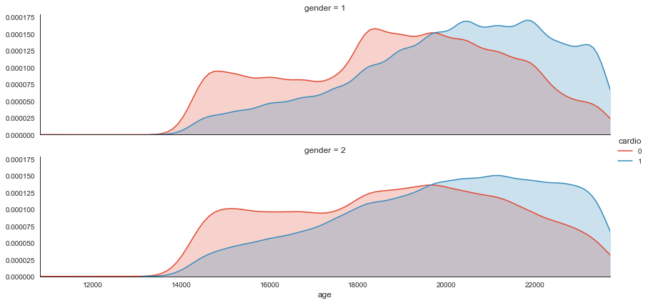

```python
plot_distribution( df , var = 'age' , target = 'cardio' , row = 'gender' )
```

###### 2.4.3.2 La taille ne semble pas associée à une maladie cardiovasculaire

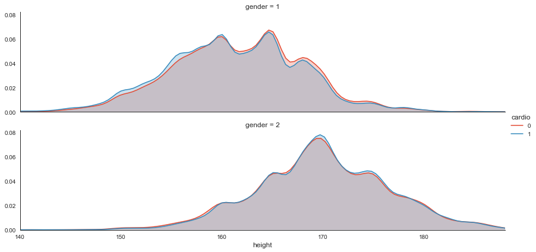

```python
plot_distribution( df , var = 'height' , target = 'cardio' , row = 'gender' )
```

###### 2.4.3.3 Plus le poids est lourd, plus le risque de maladie est élevé

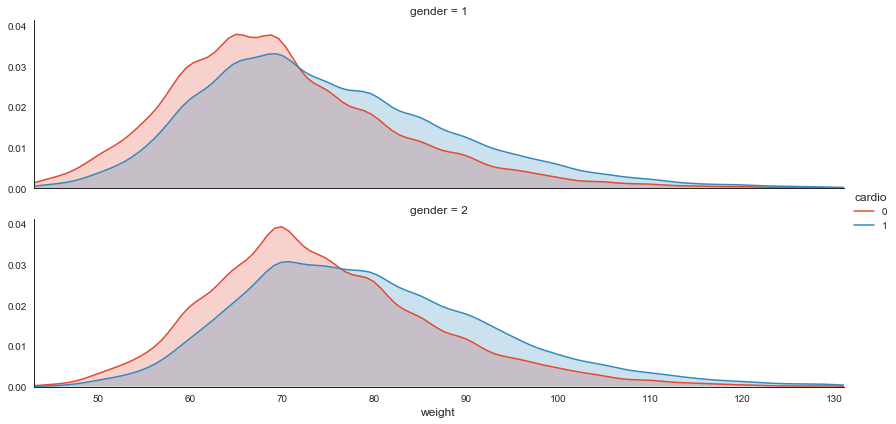

```python
plot_distribution( df , var = 'weight' , target = 'cardio' , row = 'gender' )
```

### 2.4.4 Embarqué

J'ai fait les plots de la relation entre les variables de type et la maladie cardiovasculaire On peut voir que le cholestérol et le gluc ont une plus grande relation avec la maladie cardiovasculaire

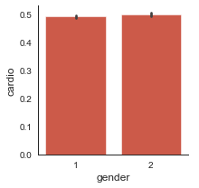

```python
#plot de gender et cardio
plot_categories( df , cat = 'gender' , target = 'cardio' )
```

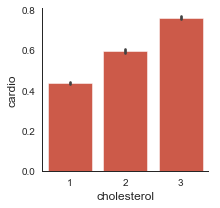

```python
#plot de cholesterol et cardio
plot_categories( df , cat = 'cholesterol' , target = 'cardio' )
```

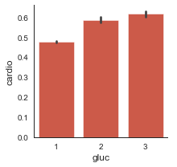

```python
#plot de gluc et cardio
plot_categories( df , cat = 'gluc' , target = 'cardio' )
```

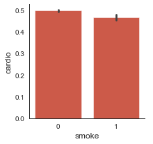

```python
#plot de smoke et cardio
plot_categories( df , cat = 'smoke' , target = 'cardio' )
```

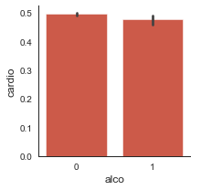

```python
#plot de alco et cardio
plot_categories( df , cat = 'alco' , target = 'cardio' )
```

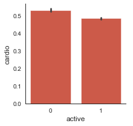

```python
#plot de active et cardio
plot_categories( df , cat = 'active' , target = 'cardio' )
```

# 3. Préparation des données

## 3.1 Conversion des variables de catégorie en variables numériques

Je souhaite convertir certains types de variables en variables numériques, car certains modèles ne peuvent reconnaître que des variables numériques. ces variables auront une valeur 1 si la ligne a une valeur particulière et une valeur 0 sinon. par exemple,Le sexe est une dichotomie et sera codé comme une variable binaire (0 ou 1).

```python
df_X = df[['years','gender','height','weight','ap_hi','ap_lo','cholesterol','gluc','smoke','alco','active']]
df_y = df.cardio
df_X.head()
```

[output not shown]

```python
#Créer une nouvelle variable pour gender
gender = pd.get_dummies( df.gender , prefix='gender' )
gender.head()
```

|  | gender_1 | gender_2 |
| --- | --- | --- |
| 0 | 0 | 1 |
| 1 | 1 | 0 |
| 2 | 1 | 0 |
| 3 | 0 | 1 |
| 4 | 1 | 0 |

```python
#Créer une nouvelle variable pour cholesterol
cholesterol = pd.get_dummies( df.cholesterol , prefix='cholesterol' )
cholesterol.head()
```

|  | cholesterol_1 | cholesterol_2 | cholesterol_3 |
| --- | --- | --- | --- |
| 0 | 1 | 0 | 0 |
| 1 | 0 | 0 | 1 |
| 2 | 0 | 0 | 1 |
| 3 | 1 | 0 | 0 |
| 4 | 1 | 0 | 0 |

```python
#Créer une nouvelle variable pour gluc
gluc = pd.get_dummies( df.gluc , prefix='gluc' )
gluc.head()
```

|  | gluc_1 | gluc_2 | gluc_3 |
| --- | --- | --- | --- |
| 0 | 1 | 0 | 0 |
| 1 | 1 | 0 | 0 |
| 2 | 1 | 0 | 0 |
| 3 | 1 | 0 | 0 |
| 4 | 1 | 0 | 0 |

```python
#Créer une nouvelle variable pour smoke
smoke = pd.get_dummies( df.smoke , prefix='smoke' )
smoke.head()
```

|  | smoke_0 | smoke_1 |
| --- | --- | --- |
| 0 | 1 | 0 |
| 1 | 1 | 0 |
| 2 | 1 | 0 |
| 3 | 1 | 0 |
| 4 | 1 | 0 |

```python
#Créer une nouvelle variable pour alco
alco = pd.get_dummies( df.alco , prefix='alco' )
alco.head()
```

|  | alco_0 | alco_1 |
| --- | --- | --- |
| 0 | 1 | 0 |
| 1 | 1 | 0 |
| 2 | 1 | 0 |
| 3 | 1 | 0 |
| 4 | 1 | 0 |

```python
#Créer une nouvelle variable pour active
active = pd.get_dummies( df.active , prefix='active' )
active.head()
```

|  | active_0 | active_1 |
| --- | --- | --- |
| 0 | 0 | 1 |
| 1 | 0 | 1 |
| 2 | 1 | 0 |
| 3 | 0 | 1 |
| 4 | 1 | 0 |

## 3.2 Créer de nouvelles variables et Supprimer les valeurs aberrantes

##### 1, j'ai remplacé l'âge par les années en tant qu'unité, afin qu'il ressemble plus à nos habitudes et qu'il soit plus facile de distinguer les mauvaises valeurs.

##### 2, je supprime les personnes dont la taille et le poids sont supérieurs à 99,75% et celles dont le poids est inférieur à 0,25%, car il est peu probable qu'une personne mesure 2m5 et pèse 200 kg.

##### 3, je supprime les données avec une pression artérielle inférieure à zéro et une pression artérielle basse supérieure à l'hypertension

##### 4, afin de supprimer les valeurs aberrantes, j'ai pris 0,25% -99,75% des données

```python
df['years'] = (df['age'] / 365).round(2)
df.drop(df[(df['height'] > df['height'].quantile(0.9975)) | (df['height'] < df['height'].quantile(0.0025))].index,inplace=True)
df.drop(df[(df['weight'] > df['weight'].quantile(0.9975)) | (df['weight'] < df['weight'].quantile(0.0025))].index,inplace=True)
df.drop(df[df['ap_lo']> df['ap_hi']].index,inplace=True)
df.drop(df[df['ap_lo']<0].index,inplace=True)
df.drop(df[df['ap_hi']<0].index,inplace=True)
df.drop(df[(df['ap_hi'] > df['ap_hi'].quantile(0.9975)) | (df['ap_hi'] < df['ap_hi'].quantile(0.0025))].index,inplace=True)
df.drop(df[(df['ap_lo'] > df['ap_lo'].quantile(0.9975)) | (df['ap_lo'] < df['ap_lo'].quantile(0.0025))].index,inplace=True)
```

```python
df.describe()
```

|  | id | age | gender | height | weight | ap_hi | ap_lo | cholesterol | gluc | smoke | alco | active | cardio | years |
| --- | --- | --- | --- | --- | --- | --- | --- | --- | --- | --- | --- | --- | --- | --- |
| count | 67802.000000 | 67802.000000 | 67802.000000 | 67802.000000 | 67802.000000 | 67802.000000 | 67802.000000 | 67802.000000 | 67802.000000 | 67802.000000 | 67802.000000 | 67802.000000 | 67802.000000 | 67802.000000 |
| mean | 49971.832704 | 19468.235037 | 1.348471 | 164.429604 | 73.998384 | 126.642621 | 81.323176 | 1.364370 | 1.225436 | 0.087564 | 0.053140 | 0.803678 | 0.494690 | 53.337622 |
| std | 28845.874929 | 2466.463191 | 0.476489 | 7.684455 | 13.694409 | 16.333641 | 9.197932 | 0.678937 | 0.571507 | 0.282662 | 0.224314 | 0.397218 | 0.499975 | 6.757413 |
| min | 0.000000 | 10798.000000 | 1.000000 | 140.000000 | 43.000000 | 90.000000 | 60.000000 | 1.000000 | 1.000000 | 0.000000 | 0.000000 | 0.000000 | 0.000000 | 29.580000 |
| 25% | 25003.750000 | 17665.000000 | 1.000000 | 159.000000 | 65.000000 | 120.000000 | 80.000000 | 1.000000 | 1.000000 | 0.000000 | 0.000000 | 1.000000 | 0.000000 | 48.400000 |
| 50% | 50011.000000 | 19703.000000 | 1.000000 | 165.000000 | 72.000000 | 120.000000 | 80.000000 | 1.000000 | 1.000000 | 0.000000 | 0.000000 | 1.000000 | 0.000000 | 53.980000 |
| 75% | 74861.750000 | 21327.000000 | 2.000000 | 170.000000 | 82.000000 | 140.000000 | 90.000000 | 1.000000 | 1.000000 | 0.000000 | 0.000000 | 1.000000 | 1.000000 | 58.430000 |
| max | 99999.000000 | 23713.000000 | 2.000000 | 188.000000 | 131.000000 | 200.000000 | 120.000000 | 3.000000 | 3.000000 | 1.000000 | 1.000000 | 1.000000 | 1.000000 | 64.970000 |

## 3.3 calculer la cote Z

Il n'est pas affecté par l'unité de mesure d'origine et peut accepter un traitement statistique ultérieur.

```python
imputed = pd.DataFrame()

imputed[ 'years' ] = df.years
imputed[ 'height' ] = df.height
imputed[ 'weight' ] = df.weight
imputed[ 'ap_hi' ] = df.ap_hi
imputed[ 'ap_lo' ] = df.ap_lo

mean = {}
for column in imputed:
    mean[column] = (imputed[column].mean(),imputed[column].std())
    imputed[column] = (imputed[column] - imputed[column].mean())/imputed[column].std()
imputed.head()
```

|  | years | height | weight | ap_hi | ap_lo |
| --- | --- | --- | --- | --- | --- |
| 0 | -0.436206 | 0.464626 | -0.876152 | -1.018917 | -0.143856 |
| 1 | 0.308162 | -1.096968 | 0.803365 | 0.817783 | 0.943345 |
| 2 | -0.248264 | 0.074227 | -0.730107 | 0.205550 | -1.231057 |
| 3 | -0.748455 | 0.594759 | 0.584298 | 1.430017 | 2.030546 |
| 4 | -0.809129 | -1.096968 | -1.314287 | -1.631150 | -2.318258 |

## 3.4 Assemblez les jeux de données finaux pour la modélisation

```python
train_df = pd.concat( [imputed,gender,cholesterol,smoke,alco,active, gluc,df.cardio] , axis=1 )
```

### 3.4.1 Sélection variable

###### Je choisis les attributs suivants pour la modélisation:

Years height weight ap_hi ap_lo gender cholesterol smoke alco active gluc

```python
train_X = pd.concat( [imputed,gender,cholesterol,smoke,alco,active, gluc] , axis=1 )
train_X.head()
```

|  | years | height | weight | ap_hi | ap_lo | gender_1 | gender_2 | cholesterol_1 | cholesterol_2 | cholesterol_3 | smoke_0 | smoke_1 | alco_0 | alco_1 | active_0 | active_1 | gluc_1 | gluc_2 | gluc_3 |
| --- | --- | --- | --- | --- | --- | --- | --- | --- | --- | --- | --- | --- | --- | --- | --- | --- | --- | --- | --- |
| 0 | -0.436206 | 0.464626 | -0.876152 | -1.018917 | -0.143856 | 0 | 1 | 1 | 0 | 0 | 1 | 0 | 1 | 0 | 0 | 1 | 1 | 0 | 0 |
| 1 | 0.308162 | -1.096968 | 0.803365 | 0.817783 | 0.943345 | 1 | 0 | 0 | 0 | 1 | 1 | 0 | 1 | 0 | 0 | 1 | 1 | 0 | 0 |
| 2 | -0.248264 | 0.074227 | -0.730107 | 0.205550 | -1.231057 | 1 | 0 | 0 | 0 | 1 | 1 | 0 | 1 | 0 | 1 | 0 | 1 | 0 | 0 |
| 3 | -0.748455 | 0.594759 | 0.584298 | 1.430017 | 2.030546 | 0 | 1 | 1 | 0 | 0 | 1 | 0 | 1 | 0 | 0 | 1 | 1 | 0 | 0 |
| 4 | -0.809129 | -1.096968 | -1.314287 | -1.631150 | -2.318258 | 1 | 0 | 1 | 0 | 0 | 1 | 0 | 1 | 0 | 1 | 0 | 1 | 0 | 0 |

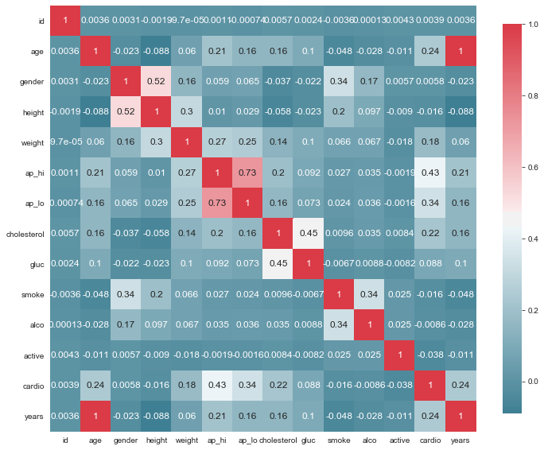

```python
plot_correlation_map( df )
```

## 3.4.2 Créer des ensembles de données

J'ai divisé 70% des données dans l'ensemble d'entraînement et 30% des données comme ensemble de test

```python
X_train,X_test,y_train,y_test = train_test_split(train_X,df_y,test_size=0.3)
```

```python
print(X_train.shape,X_test.shape,y_train.shape,y_test.shape)
```

[output not shown]

## 3.4.3 Attributs importants

J'essaye maintenant de trouver les attributs les plus importants et d'observer la différence d'avant

```
0.9995153915846695
```

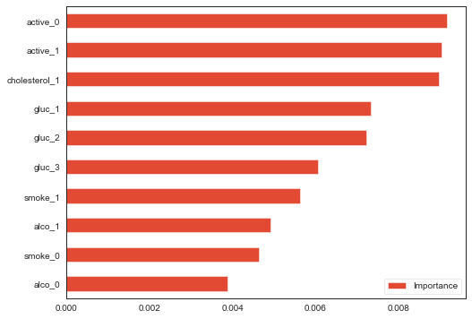

```python
plot_variable_importance(X_train, y_train)
```

# 4 Modélisation

## 4.1 Sélection du modèle

D'après les données d'analyse, nous savons que nos données prédire une catégorie, ont des étiquettes, ne sont pas text data，donc je pense que SVC est un bon modèle, testez-le d'abord

```python
model = SVC()
```

## 4.2 Former le modèle sélectionné

```python
model.fit( X_train , y_train )
x1=model.score( X_train , y_train )
y1=model.score( X_test ,y_test)
print (x1,y1)
```

```
0.7385642948947557 0.7300034413254018
```

# 5. Évaluation

## 5.1 Model performance

###### Nous pouvons utiliser l'ensemble de validation qui connaît les résultats réels pour évaluer la précision du modèle.

###### Cet ensemble de données n'a pas été utilisé pour entraîner le modèle, il est donc complètement nouveau pour le modèle,

###### et nous comparons le score de précision avec la précision lors de l'utilisation du modèle sur les données d'entraînement.

###### Si la différence entre les deux est importante, cela indique un surajustement. Et je préfère SVC car il est plus facile de procéder à une validation croisée. Si le résultat optimisé est toujours inférieur à celui d'autres modèles, je choisirai d'autres modèles pour l'optimisation

```python
#Comparer entre chaque modèle
model = RandomForestClassifier(n_estimators=100)
model.fit( X_train , y_train )
x1=model.score( X_train , y_train )
y1=model.score( X_test , y_test )
model = SVC()
model.fit( X_train , y_train )
x2=model.score( X_train , y_train )
y2=model.score( X_test , y_test )
model = GradientBoostingClassifier()
model.fit( X_train , y_train )
x3=model.score( X_train , y_train )
y3=model.score( X_test , y_test )
model = KNeighborsClassifier(n_neighbors = 3)
model.fit( X_train , y_train )
x4=model.score( X_train , y_train )
y4=model.score( X_test , y_test )
model = GaussianNB()
model.fit( X_train , y_train )
x5=model.score( X_train , y_train )
y5=model.score( X_test , y_test )
model = LogisticRegression()
model.fit( X_train , y_train )
x6=model.score( X_train , y_train )
y6=model.score( X_test , y_test )
x = [x1,x2,x3,x4,x5,x6]
y = [y1,y2,y3,y4,y5,y6]
print ("RandomForestClassifier :")
print (x1,y1)
print ("SVC :")
print (x2,y2)
print ("GradientBoostingClassifier :")
print (x3,y3)
print ("KNeighborsClassifier :")
print (x4,y4)
print ("GaussianNB :")
print (x5,y5)
print ("LogisticRegression :")
print (x6,y6)
```

```
RandomForestClassifier :
0.9994943216535682 0.7084214148763581
SVC :
0.7385642948947557 0.7300034413254018
GradientBoostingClassifier :
0.7391331830344915 0.7301017649083132
KNeighborsClassifier :
0.8197678093592634 0.6784327220883929
GaussianNB :
0.6741956553802069 0.6760237943070645
LogisticRegression :
0.7296306441077938 0.7247922914310998
```

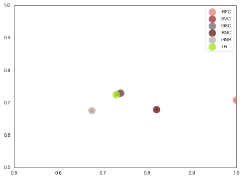

```python
plt.scatter(x,y)
plt.xlim(xmax=1,xmin=0.5)
plt.ylim(ymax=1,ymin=0.5)

plt.scatter(x1, y1,200, c='#E98484', alpha=0.8, label="RFC")

plt.scatter(x2, y2,200,  c='#9B3E3E', alpha=0.8, label="SVC")

plt.scatter(x3, y3,200,  c='#817070', alpha=0.8, label="GBC")

plt.scatter(x4, y4,200,  c='#6A2828', alpha=0.8, label="KNC")

plt.scatter(x5, y5,200,  c='#BCB4B4', alpha=0.8, label="GNB")

plt.scatter(x6, y6,200,  c='#AAE71F', alpha=0.8, label="LR")
plt.legend()
```

## 5.2 Cross-validation

J'observe d'abord la situation d'apprentissage de l'ensemble de données [0,1, 0,25, 0,5, 0,75, 1] Dans ces parties, à mesure que l'ensemble d'apprentissage augmente, le phénomène de sur-ajustement n'est pas évident.

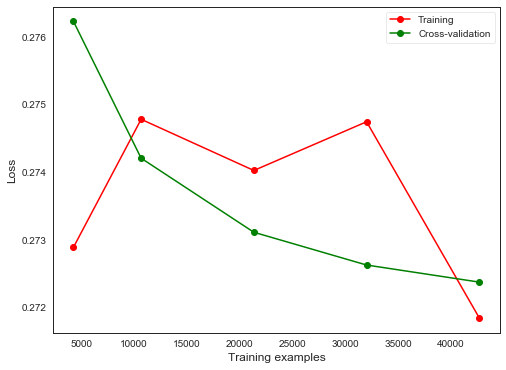

```python
train_sizes, train_loss, test_loss = learning_curve(SVC(gamma = 0.001),
         X_train , y_train,cv=10,scoring='neg_mean_squared_error',
         train_sizes = [0.1,0.25,0.5,0.75,1])
train_loss_mean = -np.mean(train_loss,axis = 1)
test_loss_mean = -np.mean(test_loss,axis = 1)
plt.plot(train_sizes,train_loss_mean,'o-',color="r",label="Training")
plt.plot(train_sizes,test_loss_mean,'o-',color="g",label="Cross-validation")
plt.xlabel("Training examples")
plt.ylabel("Loss")
plt.legend(loc="best")
plt.show()
```

## 5.2.1 Cross-validation2

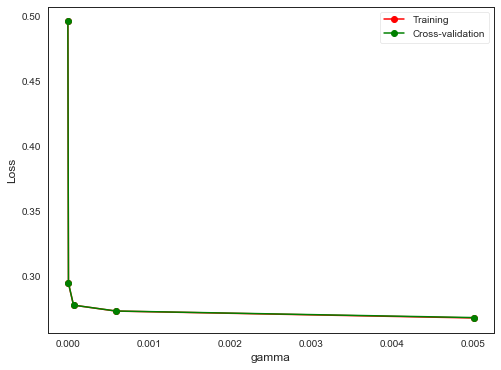

```python
param_range = np.logspace(-6,-2.3,5)

train_loss, test_loss = validation_curve(SVC(),
         X_train , y_train,param_name='gamma',param_range=param_range,cv=5,
                                         scoring='neg_mean_squared_error')
train_loss_mean = -np.mean(train_loss,axis = 1)
test_loss_mean = -np.mean(test_loss,axis = 1)
plt.plot(param_range,train_loss_mean,'o-',color="r",label="Training")
plt.plot(param_range,test_loss_mean,'o-',color="g",label="Cross-validation")
plt.xlabel("gamma")
plt.ylabel("Loss")
plt.legend(loc="best")
plt.show()
```

##### Enfin, j'ai choisi gamma = 0,1, parce qu'on peut voir que lorsque le gamma augmente, le taux d'erreur devient plus petit

```python
model = SVC(gamma=0.1)
model.fit( X_train , y_train )
x1=model.score( X_train , y_train )
y1=model.score( X_test ,y_test)
print (x1,y1)
```

```
0.7330650428773098 0.7320190747750848
```

## 5.2.2 Changer les attributs des données et supprimer les attributs subjectifs

J'ai trouvé que même si les attributs subjectifs n'apportaient pas d'avantages considérables, ces attributs subjectifs optimisaient le taux de précision, donc je pense que c'est nécessaire

```python
train_X = pd.concat( [imputed,gender,cholesterol,gluc,] , axis=1 )
```

```python
X_train,X_test,y_train,y_test = train_test_split(train_X,df_y,test_size=0.3)
```

```python
model = SVC(gamma=0.1)
model.fit( X_train , y_train )
x1=model.score( X_train , y_train )
y1=model.score( X_test ,y_test)
print (x1,y1)
```

```
0.7332968121194243 0.731674942234895
```

```python
train_X = pd.concat( [imputed,gender,cholesterol,smoke,alco,active, gluc] , axis=1 )
X_train,X_test,y_train,y_test = train_test_split(train_X,df_y,test_size=0.3)
model = SVC(gamma=0.1)
model.fit( X_train , y_train )
```

```
SVC(C=1.0, break_ties=False, cache_size=200, class_weight=None, coef0=0.0,
    decision_function_shape='ovr', degree=3, gamma=0.1, kernel='rbf',
    max_iter=-1, probability=False, random_state=None, shrinking=True,
    tol=0.001, verbose=False)
```